# cs105_phase2

```python
import pandas as pd
import numpy as np
df = pd.read_csv('CS 105 Project.csv')

df = df.set_index(['Year', 'Rank'])

df["Number of Employees"] = df["Number of Employees"].replace({'\,':''}, regex = True)
df["Number of Employees"] = df["Number of Employees"].replace({'\,':''}, regex = True)
df["Number of Employees"] = df["Number of Employees"].fillna(0)
df["Number of Employees"] = df["Number of Employees"].astype(float)

df.loc[df['Change in Rank'] == '-', 'Change in Rank'] = 0
df["Change in Rank"] = df["Change in Rank"].fillna(0)
df["Change in Rank"] = df["Change in Rank"].astype(int)

df["Revenues ($millions)"] = df["Revenues ($millions)"].replace({'\$':''}, regex = True)
df["Revenues ($millions)"] = df["Revenues ($millions)"].replace({'\,':''}, regex = True)
df["Revenues ($millions)"] = df["Revenues ($millions)"].fillna(0)
df["Revenues ($millions)"] = df["Revenues ($millions)"].astype(float)

df["Revenue Change"] = df["Revenue Change"].replace({'\%':''}, regex = True)
df.loc[df['Revenue Change'] == '-', 'Revenue Change'] = 0
df["Revenue Change"] = df["Revenue Change"].fillna(0)
df["Revenue Change"] = df["Revenue Change"].astype(float)

df["Profits ($millions)"] = df["Profits ($millions)"].replace({'\$':''}, regex = True)
df["Profits ($millions)"] = df["Profits ($millions)"].replace({'\,':''}, regex = True)
df.loc[df['Profits ($millions)'] == '-', 'Profits ($millions)'] = 0
df["Profits ($millions)"] = df["Profits ($millions)"].fillna(0)
df["Profits ($millions)"] = df["Profits ($millions)"].astype(float)

df["Profit Change"] = df["Profit Change"].replace({'\%':''}, regex = True)
df.loc[df['Profit Change'] == '-', 'Profit Change'] = 0
df["Profit Change"] = df["Profit Change"].fillna(0)
df["Profit Change"] = df["Profit Change"].astype(float)

df["Assets ($millions)"] = df["Assets ($millions)"].replace({'\$':''}, regex = True)
df["Assets ($millions)"] = df["Assets ($millions)"].replace({'\,':''}, regex = True)
df["Assets ($millions)"] = df["Assets ($millions)"].fillna(0)
df["Assets ($millions)"] = df["Assets ($millions)"].astype(float)

df["Market Value As of 3/29/19 ($m)"] = df["Market Value As of 3/29/19 ($m)"].replace({'\$':''}, regex = True)
df["Market Value As of 3/29/19 ($m)"] = df["Market Value As of 3/29/19 ($m)"].replace({'\,':''}, regex = True)
df.loc[df['Market Value As of 3/29/19 ($m)'] == '-', 'Market Value As of 3/29/19 ($m)'] = 0
df["Market Value As of 3/29/19 ($m)"] = df["Market Value As of 3/29/19 ($m)"].fillna(0)
df["Market Value As of 3/29/19 ($m)"] = df["Market Value As of 3/29/19 ($m)"].astype(float)

df.head()
#Usman
```

| Year | Rank | Company Name | Number of Employees | Change in Rank | Revenues ($millions) | Revenue Change | Profits ($millions) | Profit Change | Assets ($millions) | Market Value As of 3/29/19 ($m) |
| --- | --- | --- | --- | --- | --- | --- | --- | --- | --- | --- |
| 2019 | 1 | Walmart | 2200000.0 | 0 | 514405.0 | 2.8 | 6670.0 | -32.4 | 219295.0 | 279880.0 |
|  | 2 | Exxon Mobil | 71000.0 | 0 | 290212.0 | 18.8 | 20840.0 | 5.7 | 346196.0 | 342172.0 |
|  | 3 | Apple | 132000.0 | 1 | 265595.0 | 15.9 | 59531.0 | 23.1 | 365725.0 | 895667.0 |
|  | 4 | Berkshire Hathaway | 389000.0 | -1 | 247837.0 | 2.4 | 4021.0 | -91.1 | 707794.0 | 493870.0 |
|  | 5 | Amazon.com | 647500.0 | 3 | 232887.0 | 30.9 | 10073.0 | 232.1 | 162648.0 | 874710.0 |

Performed data cleaning on the data set.

```python
df.describe()
```

|  | Number of Employees | Change in Rank | Revenues ($millions) | Revenue Change | Profits ($millions) | Profit Change | Assets ($millions) | Market Value As of 3/29/19 ($m) |
| --- | --- | --- | --- | --- | --- | --- | --- | --- |
| count | 1.500000e+03 | 1500.000000 | 1500.000000 | 1500.000000 | 1500.000000 | 1500.000000 | 1.500000e+03 | 1500.000000 |
| mean | 5.696114e+04 | 169.955333 | 25727.784000 | 8.232400 | 2020.940800 | 42.386000 | 8.351304e+04 | 42423.356667 |
| std | 1.238835e+05 | 172.959504 | 41020.280072 | 23.497572 | 4578.042001 | 813.735767 | 2.759217e+05 | 86966.635543 |
| min | 1.260000e+02 | -131.000000 | 5145.000000 | -57.500000 | -22355.000000 | -11700.000000 | 4.370000e+02 | 0.000000 |
| 25% | 1.190000e+04 | 7.000000 | 7651.000000 | 0.000000 | 288.950000 | -16.225000 | 9.134250e+03 | 5907.750000 |
| 50% | 2.520200e+04 | 123.500000 | 12024.000000 | 5.100000 | 812.200000 | 0.900000 | 2.015800e+04 | 15753.500000 |
| 75% | 5.809925e+04 | 312.250000 | 23387.000000 | 11.725000 | 2062.500000 | 35.825000 | 5.128525e+04 | 41470.500000 |
| max | 2.300000e+06 | 761.000000 | 514405.000000 | 465.300000 | 59531.000000 | 23178.300000 | 3.418318e+06 | 904861.000000 |

This shows the overall statistics of each column in our data.

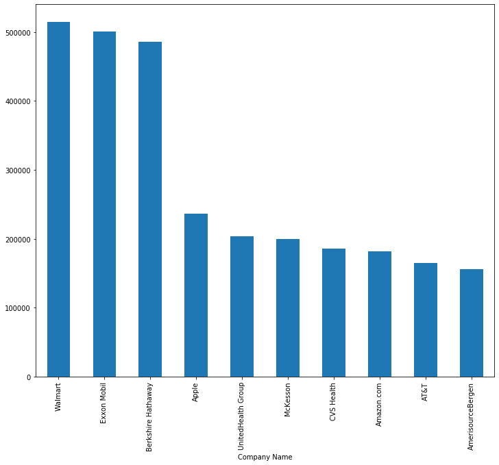

```python
import matplotlib.pyplot as plt
df1 = df[(df['Company Name'] == "Apple") | (df['Company Name'] == "Walmart") | (df['Company Name'] == "Exxon Mobil") | (df['Company Name'] == "Berkshire Hathaway") | (df['Company Name'] == "Amazon.com") | (df['Company Name'] == "UnitedHealth Group") | (df['Company Name'] == "McKesson") | (df['Company Name'] == "CVS Health") | (df['Company Name'] == "AT&T") | (df['Company Name'] == "AmerisourceBergen")]
df1.groupby('Company Name')['Revenues ($millions)'].plot(kind = 'bar', fig=(12,10))
df1.groupby(['Company Name']).mean()['Revenues ($millions)'].sort_values(ascending=False).plot(kind="bar",figsize=(12,10))
plt.show()
#Devang
```

This data appears to be skewed right since the right side of the graph appears to have a longer tail.

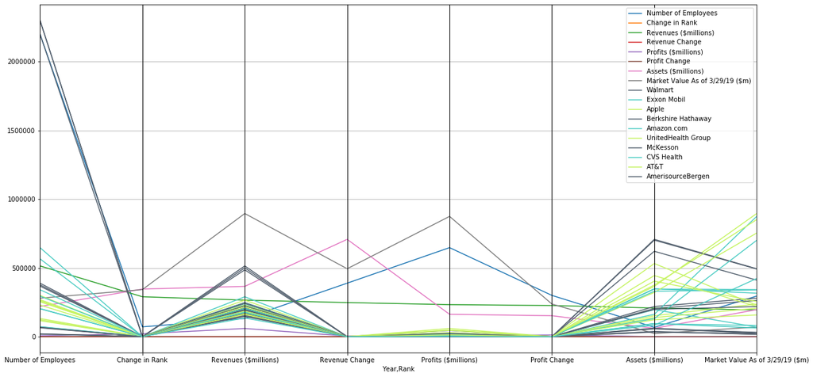

```python
import matplotlib.pyplot as plt

df1 = df[(df['Company Name'] == "Apple") | (df['Company Name'] == "Walmart") | (df['Company Name'] == "Exxon Mobil") | (df['Company Name'] == "Berkshire Hathaway") | (df['Company Name'] == "Amazon.com") | (df['Company Name'] == "UnitedHealth Group") | (df['Company Name'] == "McKesson") | (df['Company Name'] == "CVS Health") | (df['Company Name'] == "AT&T") | (df['Company Name'] == "AmerisourceBergen")]
df1.plot(figsize=(20,10))
pd.plotting.parallel_coordinates(
        df1, 'Company Name',
        color=('#556270', '#4ECDC4', '#C7F464'))
plt.show()

#Devang
```

Created a Parallel Coordinates Plot which showed the relationship between the top 10 companies and the other categorical columns.

This graph shows variability and shows the changes among the columns. There seems to be a lot of fluctuation in the top 10 companies.

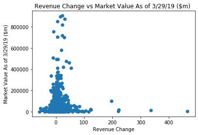

```python
fig=plt.figure()
plt.scatter(df["Revenue Change"], df["Market Value As of 3/29/19 ($m)"])
axis = fig.gca() #get current axis
axis.set_title('Revenue Change vs Market Value As of 3/29/19 ($m) ')
axis.set_xlabel('Revenue Change')
axis.set_ylabel('Market Value As of 3/29/19 ($m)')
fig.canvas.draw()
#Luis
```

Created a Scatter plot which showed the relationship between Revenue Change and Market Value.

There seems to be no significant correlation between revenue change and market value. The dots seem to clustered together and there are a few outliers.

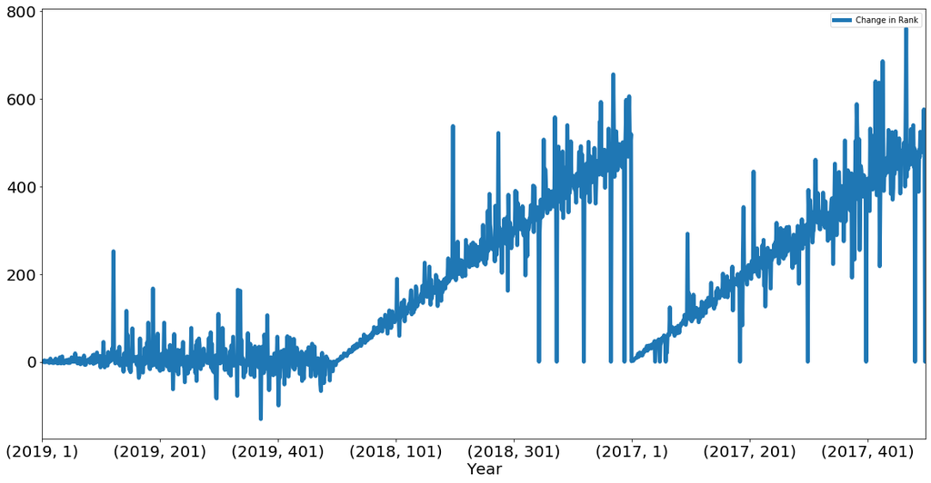

```python
df[['Change in Rank']].plot(figsize=(20,10), linewidth=5, fontsize=20)
plt.xlabel('Year', fontsize=20);
#Luis
```

Created a graph which showed the relationship between Year and Change in Rank.

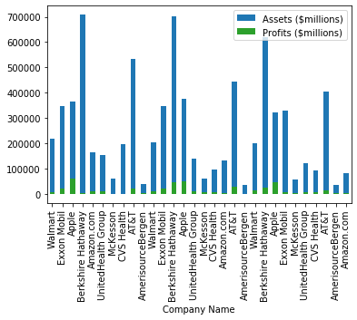

```python
df1 = df[(df['Company Name'] == "Apple") | (df['Company Name'] == "Walmart") | (df['Company Name'] == "Exxon Mobil") | (df['Company Name'] == "Berkshire Hathaway") | (df['Company Name'] == "Amazon.com") | (df['Company Name'] == "UnitedHealth Group") | (df['Company Name'] == "McKesson") | (df['Company Name'] == "CVS Health") | (df['Company Name'] == "AT&T") | (df['Company Name'] == "AmerisourceBergen")]

ax = df1.plot(x="Company Name", y="Assets ($millions)", kind="bar")
df1.plot(x="Company Name", y="Profits ($millions)", kind="bar", ax=ax, color="C2")

#Usman
```

Created a graph which showed the relationship between Company Name and Profits and Assets.

The graph appears to be skewed right.

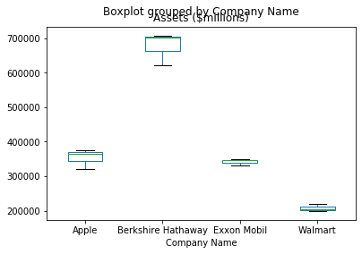

```python
df1 = df[(df['Company Name'] == "Apple") | (df['Company Name'] == "Walmart") | (df['Company Name'] == "Exxon Mobil") | (df['Company Name'] == "Berkshire Hathaway")]
df1.boxplot(by ='Company Name', column =['Assets ($millions)'], grid = False)
#Devang
```

Created a Boxplot which showed the relationship between the top 4 companies and the assets ($millions).

There seems to be a big difference in assets between the four companies. Berkshire Hathaway appears to be leading in terms of assets, even though it is not #1 on the list. Very interesting graph.

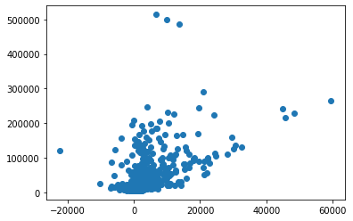

```python
import matplotlib.pyplot as plt
import pandas
plt.scatter(x=df['Profits ($millions)'], y=df['Revenues ($millions)'])
plt.show()
#Devang
```

Created a Scatter plot which showed the relationship between Profits and Revenues.